# The Cost of Our Consumption:

GDP, Energy Use, Carbon Emissions, and Changing Temperatures

Hannah Barrow

2026-02-17

## Introduction

For this data story, I am interested in how **Sustainable Development Goals 7** (affordable and clean energy), **12** (responsible consumption and production), and **13** (climate action) differ among countries with varying GDP’s. I will be using these 7 countries to investigating these relationships: the US, Germany, Egypt, India, Brazil, Australia, and Japan.

### Renewable Energy dataset

This data set if provided by [the International Renewable Energy Agency (IRENA)](https://www.irena.org/Data), an agency driving sustainable energy use world wide and providing data on renewable energy. I will be calling this dataset “energy” and filtering the data to only include the 7 countries of focus, calling that “energy_filtered”.

```
##   Country.area      Technology                    Data.Type Grid.connection
## 1    Australia Total renewable Electricity Generation (GWh)         On-grid
## 2    Australia Total renewable Electricity Generation (GWh)         On-grid
## 3    Australia Total renewable Electricity Generation (GWh)         On-grid
## 4    Australia Total renewable Electricity Generation (GWh)         On-grid
## 5    Australia Total renewable Electricity Generation (GWh)         On-grid
## 6    Australia Total renewable Electricity Generation (GWh)         On-grid
##   Year Electricity.statistics
## 1 2000               17590.10
## 2 2001               18162.10
## 3 2002               17874.10
## 4 2003               18619.10
## 5 2004               18683.10
## 6 2005               20103.10
```

### Gapminder dataset

This data set if provided by [Gapminder](https://www.gapminder.org/data/), a foundation that provides data and transparency on human living conditions and global development. I will be calling this dataset “gapminder” and filtering the data to only include the 7 countries of focus, calling that “gapminder_filtered”.

```
## # A tibble: 6 × 6
##   country   continent  year lifeExp      pop gdpPercap
##   <fct>     <fct>     <int>   <dbl>    <int>     <dbl>
## 1 Australia Oceania    1952    69.1  8691212    10040.
## 2 Australia Oceania    1957    70.3  9712569    10950.
## 3 Australia Oceania    1962    70.9 10794968    12217.
## 4 Australia Oceania    1967    71.1 11872264    14526.
## 5 Australia Oceania    1972    71.9 13177000    16789.
## 6 Australia Oceania    1977    73.5 14074100    18334.
```

### Carbon Emissions dataset

This data set if provided by the [Global Carbon Project](https://www.globalcarbonproject.org/carbonbudget/), a research project working towards spreading information and knowledge to all on the challenge of fighting climate change. I will be calling this dataset “carbon” and filtering the data to only include the 7 countries of focus, calling that “carbon_filtered”.

```
## # A tibble: 6 × 79
##   country  year iso_code population   gdp cement_co2 cement_co2_per_capita   co2
##   <chr>   <dbl> <chr>         <dbl> <dbl>      <dbl>                 <dbl> <dbl>
## 1 Austra…  1750 AUS          314500    NA         NA                    NA     0
## 2 Austra…  1751 AUS              NA    NA         NA                    NA     0
## 3 Austra…  1752 AUS              NA    NA         NA                    NA     0
## 4 Austra…  1753 AUS              NA    NA         NA                    NA     0
## 5 Austra…  1754 AUS              NA    NA         NA                    NA     0
## 6 Austra…  1755 AUS              NA    NA         NA                    NA     0
## # ℹ 71 more variables: co2_growth_abs <dbl>, co2_growth_prct <dbl>,
## #   co2_including_luc <dbl>, co2_including_luc_growth_abs <dbl>,
## #   co2_including_luc_growth_prct <dbl>, co2_including_luc_per_capita <dbl>,
## #   co2_including_luc_per_gdp <dbl>, co2_including_luc_per_unit_energy <dbl>,
## #   co2_per_capita <dbl>, co2_per_gdp <dbl>, co2_per_unit_energy <dbl>,
## #   coal_co2 <dbl>, coal_co2_per_capita <dbl>, consumption_co2 <dbl>,
## #   consumption_co2_per_capita <dbl>, consumption_co2_per_gdp <dbl>, …
```

### Levelized Cost of Energy dataset

This data set if provided by [Our World in Data](https://ourworldindata.org/grapher/levelized-cost-of-energy), an organization that provides data and infomation on global issues such as poverty, hunger, climate change, inequality, etc. I will be calling this dataset “econ” and filtering the data to only include the 7 countries of focus, calling that “econ_filtered”.

```
## # A tibble: 6 × 4
##   country    year source                     cost
##   <chr>     <dbl> <chr>                     <dbl>
## 1 Australia  2010 Bioenergy                NA
## 2 Australia  2010 Geothermal               NA
## 3 Australia  2010 Offshore wind            NA
## 4 Australia  2010 Solar photovoltaic        0.424
## 5 Australia  2010 Concentrated solar power NA
## 6 Australia  2010 Hydropower               NA
```

## The Data Story:

The data that I am using is pulled from the Carbon Emissions dataset, specifically looking at their data collection on…

1. GDP per capita,
2. Energy per capita,
3. Temperature change from CO2, and
4. CO2 per unit energy

…between the US, Germany, Egypt, India, Brazil, Australia, and Japan.

### Table showing GDP per capita, energy use per capita, CO2 emissions, and the rate of tempurature change in 7 countries in 2022

| country | gdp_per_cap | energy_per_capita | co2 | temperature_change_from_co2 |
| --- | --- | --- | --- | --- |
| India | 7349.57 | 7129.11 | 2831.166 | 0.037 |
| Egypt | 12967.95 | 9968.82 | 271.169 | 0.003 |
| Brazil | 15156.04 | 17333.80 | 483.841 | 0.055 |
| Japan | 38196.70 | 40377.67 | 1032.687 | 0.032 |
| Germany | 46495.28 | 40938.07 | 671.472 | 0.042 |
| Australia | 51305.38 | 63452.27 | 384.362 | 0.014 |
| United States | 57075.34 | 78347.91 | 5078.871 | 0.239 |

### Growth of GDP per capita in 7 countries since 1830

First, I am getting an idea of the discrepancies in GDP per capita among these 7 countries included in this analysis. It shows that the US, Australia and Germany tend to have the highest GDP’s per capita while Egypt and India have only had slight increases since the 1960’s.

[interactive chart not shown]

### Energy use per capita in 7 countries since 1965

Then, I wanted to see how these countries differ in their energy use per capita. The countries with the highest GDP’s per capita are showing similarly high energy use while the countries with the lowest GDP’s per capita also have the lowest energy use.

[interactive chart not shown]

### Temperature change from CO2 in 7 countries since 1850

I also wanted to see the impact on temperature change in these countries and see how it compares to the information in the previous figures. The US shows an increase in temperatures much greater than that of the other 6 countries.

[interactive chart not shown]

### CO2 emissions per unit of energy in 7 countries over the past 20 years

I saw that there was data on the CO2 emissions per unit energy and I wanted to see what this looked like in these countries, now keeping in mind their GDP per capita and their energy use per capita. It shows that India, the country with the lowest GDP and the lowest energy use per capita, has the highest CO2 emissions per unit of energy of all 7 countries over the past 20 years. Australia, a country with a high GDP and a high energy use per capita, also has high CO2 emissions per unit of energy, even higher than the US. I also found it interesting that Brazil, Germany, and the US have the lowest CO2 emissions per unit of energy but were also the 3 countries with the highest temperature change from CO2.

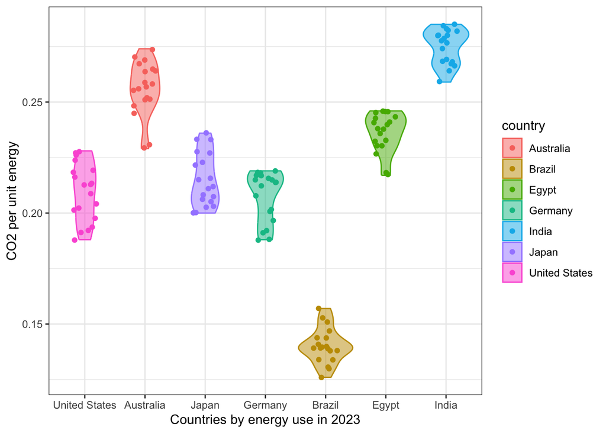

### Energy per capita compared to tempurature change in 7 countries over the past 20 years

Finally, I wanted to see the relationship between energy use and temperature change in these countries. India and Brazil, the countries with some of the the lowest GDP and energy use per capita, are the only two that show an increase in temperature change as energy use per capita increases. While the rest generally show a decrease in temperature even as they are using more energy, Australia and the US having the steepest slopes.

[interactive chart not shown]

## Takeaways

The wealthiest countries per capita also tend to be the countries that are using the most energy. But interestingly enough, they are not the ones seeing the increases in temperatures as their energy consumption increases. For example, as energy consumption increases in the US, temperature change decreases, as you can see above.

The *consequences* of consumption are not often manifested in the same countries that are the *sources*. Countries with enough money to push the problems elsewhere or that better financially support relief and preventative measures are also often the ones causing the greatest damage and not facing the hardest consequences.

Sustainable Development Goals 12 is a particularly important goal that bleeds into so many others. If we want to think about energy and our climate crisis, we have to face reality and consider what we are consuming and just how many consequences there are that we might not see.